# Model_2

${\huge{Linear}{~}{Regression}{~}{Modeling}{~}{-}{~}{Electronic}{~}{Switch}{~}{Failure}}$

One way of looking at linear regression models is to think of them as modeling ${RESPONSE} = {STIMULUS} + {ERROR}$. In other words, the response (or dependent variable or target value or predicted value) ${(Y)}$ is related linearly to a stimulus (or independent variable or predictor) ${(X)}$ plus some error ${(e)}$. To see how it fits in with some related models, please see the summary below.

### In ANOVA the stimulus is fixed

${\large{Y} = {X} + {error}}$

### In Regression the stimulus is random

${\large{Y} = {\beta}{X}+{error}}$

### In Factor Analysis the stimulus is latent

${\large{Y} = {\lambda}{X} + {error}}$

# -------------------------------------------------------------------------------

${\huge{Simple}{~}{Linear}{~}{Regression}{~}{Model}}$

The simple linear regression model is based on a set of ordered pairs (i.e. sample data) where the i-th ordered pair are related to each other as follows.

$${\Large {y_i = {a}{~}+{~}{bx_i}{~}+{~}{e_i}}} $$

We also know that the i-th predicted response $({\hat{y_i}})$ is defined as follows.

$${\Large{\hat{y_i}}={a}{~}+{~}{bx_i}}$$

Thereby allowing for the calculation of the error (also known as the residual).

$${\Large{y_i} - {\hat{y_i}}={e_i}}$$

Since the error can be positive or negative, the error is squared. Summing all of the squared errors gives us the Sum of Squared Errors - ${{SSE}}$.

$$\Large{SSE =}\sum\limits_{i=1}^n (y_i-{\hat{y_i})^2}$$

Develpoment of the regression line ${a}{~}+{~}{bx_i}$ is based on minimizing the ${SSE}$.

Once the simple linear regression model has been developed it is necessary to check if the model is appropriate. This is accomplished by checking the assumptions associated with linear regression. The assumptions are that the errors, $e_i$ are independent, normally distributed, random variables with a mean of zero and a constant variance, $\sigma_i^2$. Residual analysis is used to determine the fitness of applying linear regression.

# -------------------------------------------------------------------------------

# Example - Model failure of a new electronic switch

In this example a company has just developed a new electronic switch. The company is concerned about warranty claims and wants to be able to provide customers with the ability to predict the failure rate of the switch.

Using Python and data provided by the engineering group, attempt to develop a Linear Regression model that the company can use to avoid warranty claims.

Import Python libraries.

```python
#import pandas as pd
import numpy as np
import matplotlib.pyplot as plt
from sklearn.linear_model import LinearRegression
from sklearn.metrics import r2_score
import statsmodels.api as sm
```

In order to get a feel for the data a scatter plot is created; the Number of Cycles, the proposed predictor, is graphed on the x-axis, the Failure Rate, the predicted variable, is graphed on the y-axis. The scatter plot, as shown below, appears to indicate that the data is not well-behaved (i.e. not linear throughout the full span of data).

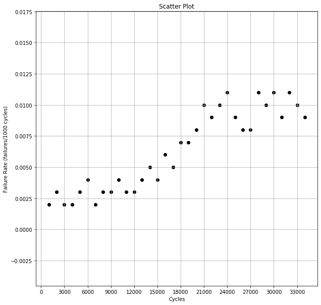

```python
lst_obs_cycles_x = [1000,2000,3000,4000,5000,6000,7000,8000,9000,10000,11000,12000,13000,14000,15000,16000,17000,18000,19000,20000,21000,22000,23000,24000,25000,26000,27000,28000,29000,30000,31000,32000,33000,34000]
lst_obs_failure_rate_y = [0.002,0.003,0.002,0.002,0.003,0.004,0.002,0.003,0.003,0.004,0.003,0.003,0.004,0.005,0.004,0.006,0.005,0.007,0.007,0.008,0.010,0.009,0.010,0.011,0.009,0.008,0.008,0.011,0.010,0.011,0.009,0.011,0.010,0.009]


plt.figure(figsize=(10, 10))
plt.scatter(lst_obs_cycles_x, lst_obs_failure_rate_y, c='black')

plt.xlabel("Cycles")
plt.ylabel('Failure Rate (failures/1000 cycles)')
plt.title('Scatter Plot')
plt.xticks(np.arange(0, 35000, 3000))
plt.grid()
plt.show()
```

Next, a histogram of the failure rates is plotted. The histogram, as displayed below, confirms that the data is bimodal in nature. Returning back to look at the scatter plot, the only opportunity to apply a linear regression model is for failure rates between 12000 cycles and 24000 cycles.

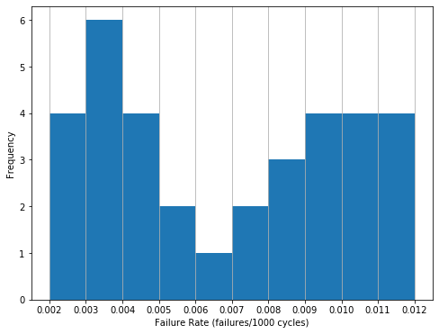

```python
plt.figure(figsize=(8,6))
plt.hist(lst_obs_failure_rate_y, bins=(0.002,0.003,0.004,0.005,0.006,0.007,0.008,0.009,0.010,0.011,0.012))

plt.xticks(np.arange(0.002,0.013,0.001))
plt.grid(axis='x', linestyle='solid')
plt.xlabel('Failure Rate (failures/1000 cycles)')
plt.ylabel('Frequency')
plt.show()
```

Because the data is not well-behaved, a subset of the data, focusing on the cycles between 12000 and 24000, is created. At the same time, engineering has supplied run time data in minutes, hoping that time, as an added predictor, may provide additional information to the regression analysis - this data will be used later in the analysis.

Using the number of cycles subset of data and the associated observed failure rates, a regression plot (or fitted line plot) is shown below. The newly generated equation for the regression line is displayed just above the graph.

```
The Linear Regression Model is: Y = -0.00482 + 6.48e-07 X_cycles
```

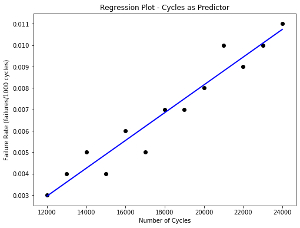

```python
sm_lst_cycles_x = [12000,13000,14000,15000,16000,17000,18000,19000,20000,21000,22000,23000,24000]
new_lst_time_x = [3300,5500,6100,2200,7500,4500,5900,7500,8200,9000,12000,9600,11000]
sm_lst_failure_rate_y = [0.003,0.004,0.005,0.004,0.006,0.005,0.007,0.007,0.008,0.010,0.009,0.010,0.011]

sm_array_failure_rate_y = np.array(sm_lst_failure_rate_y)



sm_array_cycles_x = np.array(sm_lst_cycles_x)
new_array_time_x = np.array(new_lst_time_x)


X = sm_array_cycles_x.reshape(-1,1)
X2 = new_array_time_x.reshape(-1,1)
y = sm_array_failure_rate_y.reshape(-1,1)


Xs=np.hstack((X,X2))

reg = LinearRegression()
# Train the model
reg.fit(X, y)
print("")
print("The Linear Regression Model is: Y = {:.3} + {:.3} X_cycles".format(reg.intercept_[0], reg.coef_[0][0]))
print("")


# Shows the Predicted Line
predictions = reg.predict(X)
plt.figure(figsize=(8, 6))
plt.plot(sm_lst_cycles_x, predictions, c='blue', linewidth=2)
plt.scatter(sm_lst_cycles_x, sm_lst_failure_rate_y, c='black')

plt.xlabel("Number of Cycles")
plt.ylabel('Failure Rate (failures/1000 cycles)')
plt.title("Regression Plot - Cycles as Predictor")
plt.show()
```

The fitted line plot suggests that there is an increasing linear relationship between the number of cycles and the failure rate. The plot appears to indicate that there are no unusual data points in the data set and it the variation around the regression line would seem to support the assumption of equal error variances. However, to confirm these observations the next plot to be created and reviewed is the residuals and fits plot (please see below).

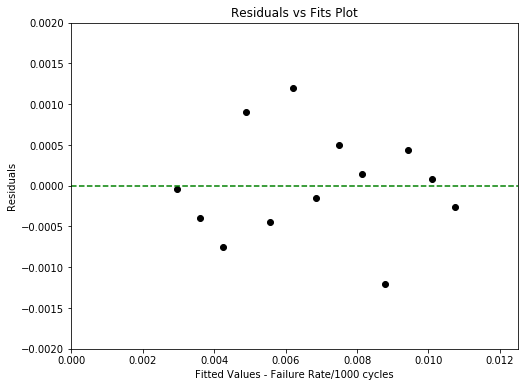

```python
## Residual vs Fits - Based on Number of Cycles

residual=[]

flatlist=[]
for elem in predictions:
    for item in elem:
        flatlist.append(item)
#
for i in range (len(flatlist)):
    residual.append(flatlist[i] - sm_lst_failure_rate_y[i])

plt.figure(figsize=(8, 6))
plt.ylim(-.002,.002)
plt.xlim(0, 0.0125)
plt.scatter(flatlist, residual, c='black')
plt.axhline(y=0, color='g', linestyle='--')
plt.title('Residuals vs Fits Plot')
plt.xlabel('Fitted Values - Failure Rate/1000 cycles')
plt.ylabel('Residuals')
plt.show()
```

First, it is known that any data point that falls directly on the regression line will have a residual of 0; as a result, the residual = 0 line directly corresponds to the regression line. Second, the residuals vs. fits plot appears to be well-behaved and confirms the following assumptions when applying a linear regression model:

- The residuals appear to be randomly distributed around the residual = 0 line. This supports the assumption that the relationship is linear.
- The residuals form a horizontal band around the residual = 0 line. This supports the assumption that the variances of the errors are approximately equal.
- There are no residuals that stand out from the rest. This supports the assumption of no outliers.

Next, please see the coefficient of determination below.

```python
print('Coefficient of Determination: %.3f' % r2_score(sm_lst_failure_rate_y, predictions))
```

```
Coefficient of Determination: 0.937
```

The coeficient of determination $(r^2)$ represents the portion of the variation of the dependent variable (the failure rate/1000 cycles) that is explained by the independent variable (the number of cycles). If all of the variation in the dependent variable had been explained by the predictor then $(r^2)$ would have been equal to one (1). This, along with the residuals analysis, supports the application of the regression model.

Finally, the creation of a residuals vs. predictor plot will assist in determining the value of the time data that was submitted by the engineering team. In this type of plot the residuals (plotted on the y-axis) already include failure rate adjusted for number of cycles; the new predictor, time, is plotted on the x-axis. If the residuals vs. predictor plot displays a non-random pattern, it indicates that the predictor explains some of the remaining variability in the residuals. This would support the addition of another independent variable to the model, leading to the development of a multiple regression model.

Please see the residuals vs predictor plot below.

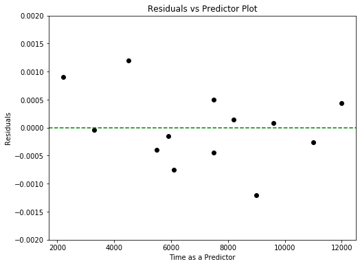

```python
plt.figure(figsize=(8, 6))
plt.ylim(-.002,.002)
#plt.xlim(0, 0.0125)
plt.scatter(new_lst_time_x, residual, c='black')
plt.axhline(y=0, color='g', linestyle='--')
plt.title('Residuals vs Predictor Plot')
plt.xlabel('Time as a Predictor')
plt.ylabel('Residuals')
plt.show()
```

The residuals vs. predictor, as seen above, does not display a pattern. Therefore, adding the predictor time will not explain any of the remaining variability in the response.

The conclusion, the company can use the derived regression equation ${(y_{failure{~}rate} = -0.00482 + 6.48{\centerdot}10^{-7}x_{cycles})}$ to assist customers forecast the electronic switch failure based on the number of cycles. The one caveat is that the model is only applicable for the range of cycle numbers between 12000 and 24000 inclusive.